# Histogram, frequency plots

Nithiyashri Jayashankar

Libraries

```r
library("here")
library("tidyverse")
library("broom")
library("ggprism")
library("patchwork")
library("RColorBrewer")
library("ggridges")
```

# Loading Data

```r
normalized_counts <- read_rds(file = here("data/03_normalized_counts.Rdata"))
non_normalized_counts <- read_tsv(file = here("data/03_non-normalized_counts.tsv"))
full_data <- read_tsv(file = here("data/03_full_data.tsv"))
```

# Data wrangling

The sum of all the gene counts across all samples for each gene is obtained here. This is done for both normalized and non-normalized gene counts.

The sums is then obtained and using c bind it is attached together.

```r
normalized <- normalized_counts |>
  select(where(is.numeric))
normalized_sums <- rowSums(normalized)

non_normalized<- non_normalized_counts |>
  select(where(is.numeric))
non_normalized_sums <-rowSums(non_normalized)

normalized_sums
```

[output not shown]

[output cut: 98 more lines]

```r
non_normalized_sums
```

[output not shown]

[output cut: 63 more lines]

```r
joined = cbind(non_normalized_sums, normalized_sums)
```

## Histograms of normalized and non-normalized gene counts

The sums of the normalized and non-normalized were plotted as histograms.

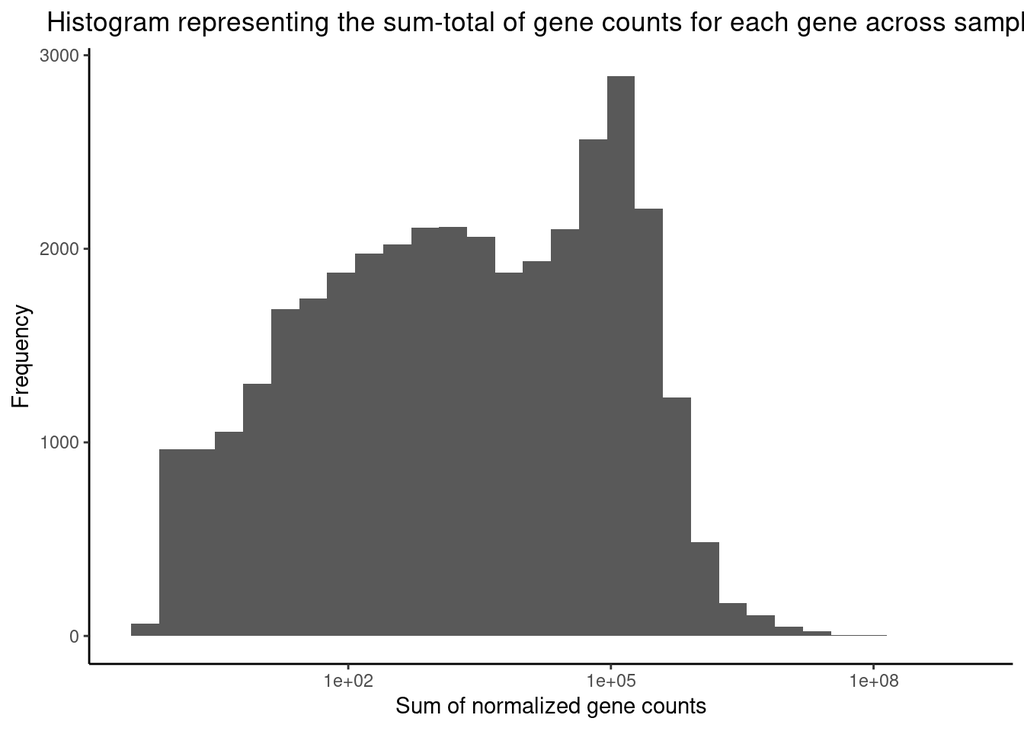

```r
P1 <- ggplot(joined, aes(x=normalized_sums))+
  geom_histogram()+
  scale_x_log10()+
  labs(
    title = "Histogram representing the sum-total of gene counts for each gene across samples",
    x = "Sum of normalized gene counts",
    y = "Frequency"
  ) +
  theme_classic() +
  theme(
    legend.position = "top",
    plot.title = element_text(hjust = 0.5)
  )
P1
```

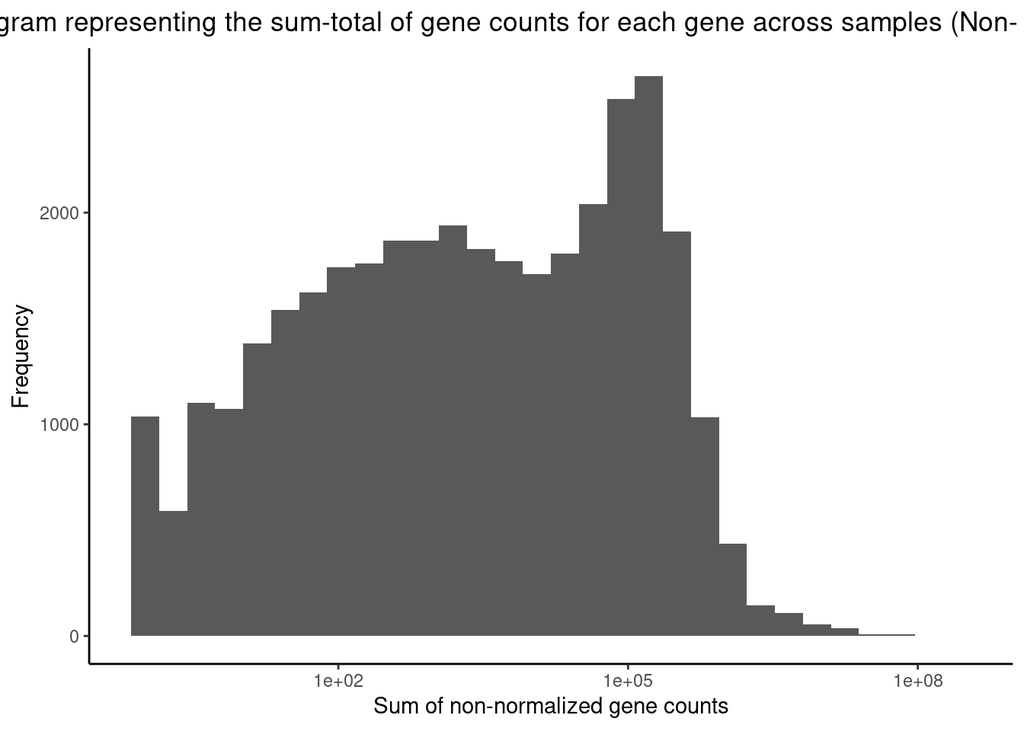

```r
P2 <- ggplot(joined, aes(x=non_normalized_sums))+
  geom_histogram()+
  scale_x_log10()+
  labs(
    title = "Histogram representing the sum-total of gene counts for each gene across samples (Non- normalized)",
    x = "Sum of non-normalized gene counts",
    y = "Frequency"
  ) +
  theme_classic() +
  theme(
    legend.position = "top",
    plot.title = element_text(hjust = 0.5)
  )

P2
```

The effect of normalization is not very apparent from these graphs.

### Adding gene names to non-normalized dataframe.

The gene names had to be extracted form the normalized dataframe to add to the non-normalized data fram

```r
non_normalized_counts_new <- non_normalized_counts |>
  mutate(gene = normalized_counts$gene)

non_normalized_counts_new <- non_normalized_counts_new |>
  select(gene, everything())


normalized_counts <- normalized_counts |>
  select(gene, everything())
```

## Data wrangling for Geom Density plots:

Non-normalised count data was pivotted longer - this helps with merging with the full data so we get an entire data frame consisting of normalised and non-normalized gene counts side by side.

```r
non_norm_count_data_long <- non_normalized_counts_new |>
  pivot_longer(
  cols = -1,
  names_to = "sample",
  values_to = "non_norm_counts")
  print(non_norm_count_data_long)
```

[output not shown]

```r
merged_data <- full_data |>
  left_join(non_norm_count_data_long,
            by = c("sample", "gene"))
```

## Density graphs

Here, it is ensure that the variable diagnosis is considered a factor which helps compare between MDS and HD patients.

## Density graphs pl1 and pl2

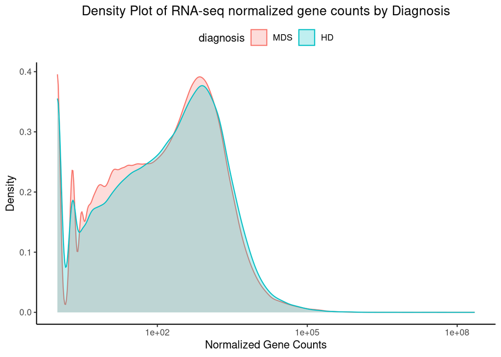

```r
merged_data <- merged_data |>
  mutate(diagnosis = factor(diagnosis, levels = c("MDS", "HD")))


pl1 <- ggplot(merged_data, aes(x = counts, fill = diagnosis, color = diagnosis)) +
  geom_density(alpha = 0.25) +
  scale_x_log10() +
  labs(
    title = "Density Plot of RNA-seq normalized gene counts by Diagnosis",
    x = "Normalized Gene Counts",
    y = "Density"
  ) +
  theme_classic() +
  theme(
    legend.position = "top",
    plot.title = element_text(hjust = 0.5)
  )


pl1
```

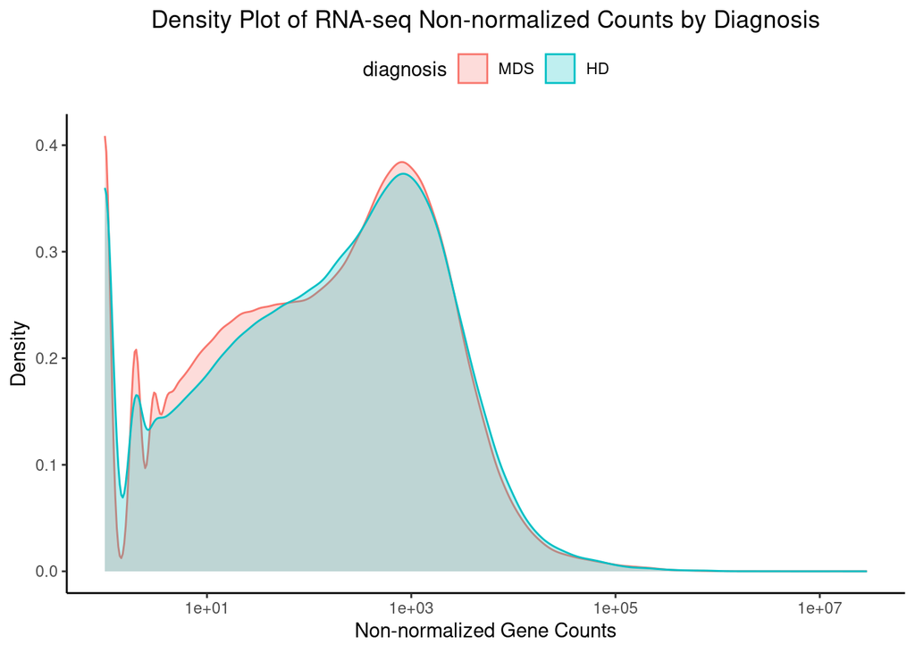

```r
pl2 <- ggplot(merged_data, aes(x = non_norm_counts, fill = diagnosis, color = diagnosis)) +
  geom_density(alpha = 0.25) +
  scale_x_log10() +
  labs(
    title = "Density Plot of RNA-seq Non-normalized Counts by Diagnosis",
    x = "Non-normalized Gene Counts",
    y = "Density"
  ) +
  theme_classic() +
  theme(
    legend.position = "top",
    plot.title = element_text(hjust = 0.5)
  )

pl2
```

From the above graphs, the effect of normalization is not very apparent.

## Histogram - Representing gene expression, factored on diagnosis

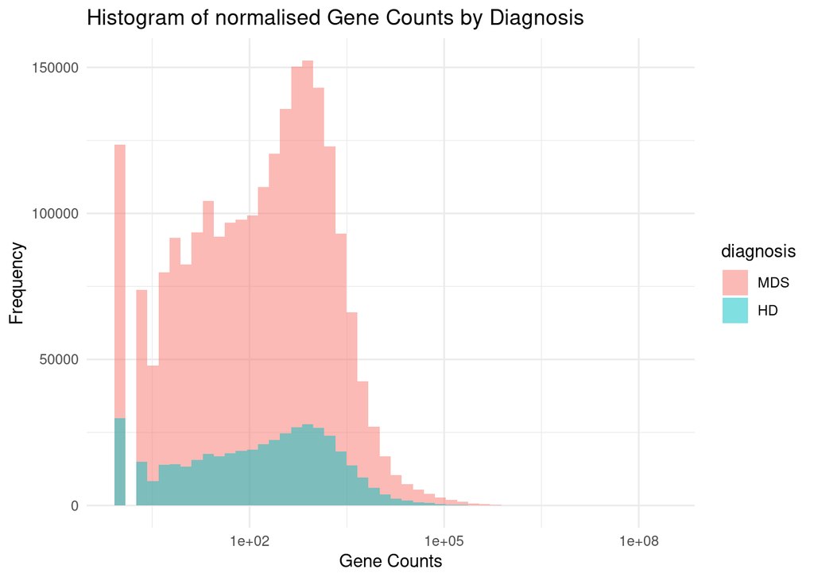

```r
histrogram_plot_normalized <- ggplot(merged_data, aes(x = counts,
                        fill = diagnosis)) +
  geom_histogram(alpha = 0.5,
                 position = "identity",
                 bins = 50) +
  scale_x_log10() +
  labs(title = "Histogram of normalised Gene Counts by Diagnosis",
       x = "Gene Counts",
       y = "Frequency") +
  theme_minimal()
histrogram_plot_normalized
```

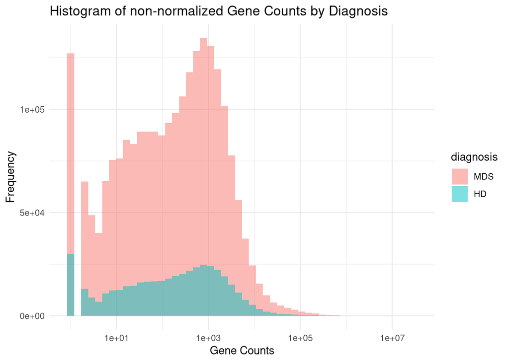

```r
ggsave(plot = histrogram_plot_normalized,
       filename = here("images/plot_histogram_plot_normalized.png"))
histogram_plot_non_norm <- ggplot(merged_data, aes(x = non_norm_counts,
                        fill = diagnosis)) +
  geom_histogram(alpha = 0.5,
                 position = "identity",
                 bins = 50) +
  scale_x_log10() +
  labs(title = "Histogram of non-normalized Gene Counts by Diagnosis",
       x = "Gene Counts",
       y = "Frequency") +
  theme_minimal()

histogram_plot_non_norm
```

```r
ggsave(plot = histogram_plot_non_norm,
       filename = here("images/plot_histogram_plot_non_normalized.png"))
```

## ECDF Plot

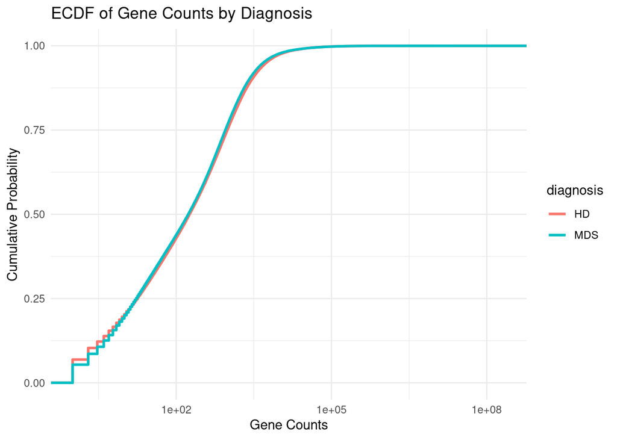

```r
ggplot(full_data, aes(x = counts, color = diagnosis)) +
  stat_ecdf(size = 1) +
  scale_x_log10() +
  labs(title = "ECDF of Gene Counts by Diagnosis",
       x = "Gene Counts",
       y = "Cumulative Probability") +
  theme_minimal()
```